# GLMs and Poisson regression

Peter Ralph

26 November 2019 – Advanced Biological Statistics

# Math minute: matrix multiplication

To simulate from:
$$\begin{aligned}
\mu_i &= b_0 + b_1 X_{i1} + \cdots + b_k X_{ik} \\
Y_i &\sim \Normal(\mu_i, \sigma) .
\end{aligned}$$

either

```r
coefs <- list(b0=1.0, b=c(3.0, -1.0, 0.0, 0.0),
              sigma=0.5)
n <- 200
X <- matrix(rnorm(4*n, mean=0, sd=3), ncol=4)
Y <- coefs$b0
for (k in 1:ncol(X)) {
    Y <- Y + coefs$b[k] * X[,k]
}
Y <- Y + rnorm(n, mean=0, sd=coefs$sigma)
```

To simulate from:
$$\begin{aligned}
\mu_i &= b_0 + b_1 X_{i1} + \cdots + b_k X_{i1} \\
Y_i &\sim \Normal(\mu_i, \sigma) .
\end{aligned}$$

of

```r
coefs <- list(b0=1.0, b=c(3.0, -1.0, 0.0, 0.0),
              sigma=0.5)
n <- 200
X <- matrix(rnorm(4*n, mean=0, sd=3), ncol=4)
Y <- coefs$b0 + X %*% coefs$b + rnorm(n, mean=0, sd=coefs$sigma)
```

## Because

In R, `%*%` is *matrix multiplication*: if

- $b$ is a $k$-vector
- $X$ is an $n \times k$ matrix

then `X %*% b` (or, $X b$ in math notation) is shorthand for the $n$-vector
$$(Xb)_i = \sum_{j=1}^k X_{ij} b_j .$$

In Stan, matrix multiplication is `*`.

# A note on impostor syndrome

[figure not shown]

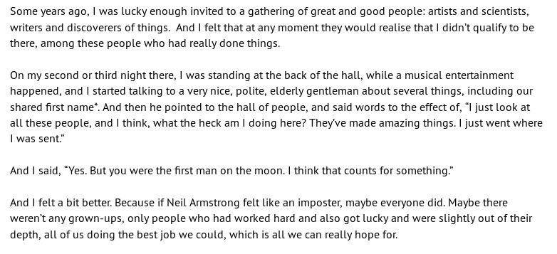

# Generalized Linear Models

## Ingredients of a GLM:

1. A probability distribution, $Y$.

> *(the “family”; describes the output)*
2. A linear predictor, $X \beta$.

> *(connects input to output)*
3. A link function (usually, $h(\E[Y]) = X\beta$).

> *(connects linear predictor to probability distribution)*

## Common choices:

- Linear regression:
  $$Y \sim \Normal(X \beta, \sigma) .$$
- Logistic regression:
  $$Y \sim \Binom(n, \logistic(X\beta)) .$$
- Gamma regression:
  $$Y \sim \Gam(\text{scale}=\exp(X\beta)/k, \text{shape}=k) .$$

## Logistic regression, in R

```
glm(y ~ x, family=binomial)
```

```
family {stats}

Family objects provide a convenient way to specify the details of the models
used by functions such as glm.

binomial(link = "logit")
gaussian(link = "identity")
Gamma(link = "inverse")
inverse.gaussian(link = "1/mu^2")
poisson(link = "log")

Arguments

link: a specification for the model link function. This can be a
name/expression, a literal character string, a length-one character vector, or
an object of class "link-glm" (such as generated by make.link) provided it is
not specified via one of the standard names given next.

The gaussian family accepts the links (as names) identity, log and inverse; the
binomial family the links logit, probit, cauchit, (corresponding to logistic,
normal and Cauchy CDFs respectively) log and cloglog (complementary log-log);
the Gamma family the links inverse, identity and log; the poisson family the
links log, identity, and sqrt; and the inverse.gaussian family the links
1/mu^2, inverse, identity and log.
```

Note that the link function is the *inverse* of what we’d write down in the model: for instance, if the mean of the response is the exponential of the linear predictor, i.e., if
$$\E[Y] = \exp(X\beta) .$$
then we have

```
link = "log"
```

Other inverses:

- `logistic` has inverse `logit`
- `identity` has inverse `identity`
- `x^2` (“squared”) has inverse `sqrt`

# Unpacking logistic regression

## Simulate data

100 trials, where probability of success depends on $x$:

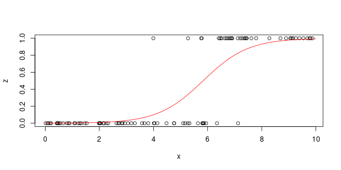

```r
alpha <- -7; beta <- 1.2
x <- runif(100, 0, 10)
y <- alpha + beta * x
p <- 1 / (1 + exp(-y))
z <- rbinom(100, size=1, prob=p)
plot(z ~ x)
curve(1/(1+exp(-(-7 + 1.2 *x))), 0, 10, col='red', add=TRUE)
```

## `glm()`

```r
zz <- cbind(z, 1-z)
summary(glm_fit <- glm(zz ~ x, family='binomial'))
```

```
##
## Call:
## glm(formula = zz ~ x, family = "binomial")
##
## Deviance Residuals:
##      Min        1Q    Median        3Q       Max
## -2.21167  -0.07659  -0.00864   0.16365   2.72105
##
## Coefficients:
##             Estimate Std. Error z value Pr(>|z|)
## (Intercept) -11.3818     3.0318  -3.754 0.000174 ***
## x             1.9278     0.4963   3.884 0.000103 ***
## ---
## Signif. codes:  0 '***' 0.001 '**' 0.01 '*' 0.05 '.' 0.1 ' ' 1
##
## (Dispersion parameter for binomial family taken to be 1)
##
##     Null deviance: 133.750  on 99  degrees of freedom
## Residual deviance:  37.267  on 98  degrees of freedom
## AIC: 41.267
##
## Number of Fisher Scoring iterations: 8
```

## Stan

$$\begin{aligned}
Z &\sim \Binom(1, P) \\
P &= \logistic(\alpha + \beta X)
\end{aligned}$$

```r
logistic_block <- "
data {
    int N;
    vector[N] X;
    int<lower=0> Z[N];
}
parameters {
    real alpha;
    real beta;
}
model {
    vector[N] p;
    p = inv_logit(alpha + beta * X);
    Z ~ binomial(1, p);
}"
```

## Stan: fit the model

```r
fit <- stan(model_code=logistic_block,
            data=list(N=100, X=x, Z=z))
rstan::summary(fit)$summary
```

```
##             mean    se_mean        sd      2.5%        25%        50%        75%      97.5%    n_eff     Rhat
## alpha -12.579330 0.12448956 3.2416087 -20.08699 -14.562301 -12.263318 -10.229706  -7.121727 678.0401 1.001617
## beta    2.123924 0.02026774 0.5305953   1.22808   1.736981   2.071771   2.442721   3.340106 685.3559 1.001303
## lp__  -19.641846 0.03384329 1.0367456 -22.47400 -20.010380 -19.311850 -18.917676 -18.658669 938.4245 1.003825
```

## Stan: posterior distributions

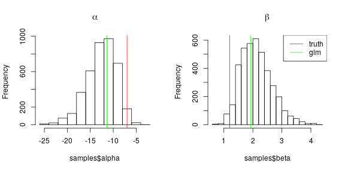

```r
samples <- extract(fit)
layout(t(1:2))
hist(samples$alpha, main=expression(alpha))
abline(v=alpha, col='red'); abline(v=coef(glm_fit)[1], col='green')
hist(samples$beta, main=expression(beta))
abline(v=beta, col='red'); abline(v=coef(glm_fit)[2], col='green')
legend("topright", lty=1, col=c('red', 'green'), legend=c('truth', 'glm'))
```

# Identify the GLM

```
data {
  int N;
  vector[N] X;
  vector[N] Y;
  vector<lower=0> Z[N];
}
parameters {
  real beta[2];
}
model {
  Z ~ gamma(1, exp(- beta[1] * X - beta[2] * Y));
}
```

What is

1. the probability distribution? *(describes the output)*
2. the linear predictor? *(connects input to output)*
3. the link function? *(connects linear predictor to probability distribution)*

**Then,** simulate from it.

## in class

```r
N <- 100
# Matrix of X, Y
XY <- cbind(X=rnorm(N),
            Y=rnorm(N))
beta <- c(2, -3)
# Xbeta <- beta[1] * X + beta[2] * Y
Xbeta <- XY %*% beta
Z <- rgamma(N, shape=1, scale=exp(-Xbeta))

gZ <- glm(Z ~ XY[,"X"] + XY[,"Y"], family=Gamma(link='log'))
summary(gZ)
```

```
##
## Call:
## glm(formula = Z ~ XY[, "X"] + XY[, "Y"], family = Gamma(link = "log"))
##
## Deviance Residuals:
##     Min       1Q   Median       3Q      Max
## -3.3130  -0.9182  -0.3895   0.3900   1.7129
##
## Coefficients:
##             Estimate Std. Error t value Pr(>|t|)
## (Intercept)  0.10181    0.09629   1.057    0.293
## XY[, "X"]   -2.03873    0.10828 -18.829   <2e-16 ***
## XY[, "Y"]    3.00499    0.09137  32.888   <2e-16 ***
## ---
## Signif. codes:  0 '***' 0.001 '**' 0.01 '*' 0.05 '.' 0.1 ' ' 1
##
## (Dispersion parameter for Gamma family taken to be 0.9192264)
##
##     Null deviance: 1151.41  on 99  degrees of freedom
## Residual deviance:  126.36  on 97  degrees of freedom
## AIC: 233.01
##
## Number of Fisher Scoring iterations: 8
```

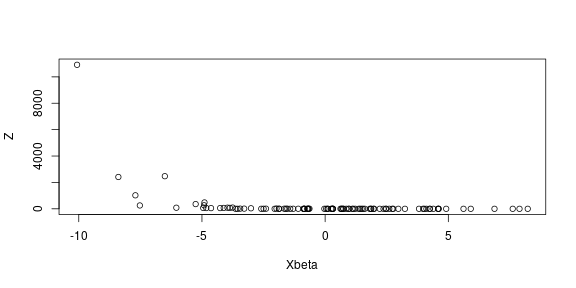

```r
plot(Xbeta, Z)
```

# Stochastic minute

## The Poisson distribution

If $N \sim \Poisson(\mu)$ then $N \ge 0$ and
$$\begin{aligned}
\P\{N = k\} = \frac{\mu^k}{k!} e^{-\mu}
\end{aligned}$$

- $N$ is a nonnegative integer (i.e., a *count*)
- $\E[N] = \var[N] = \mu$
- If a machine makes widgets very fast, producing on average one broken widget per minute (and many good ones), each breaking independent of the others, then the number of broken widgets in $\mu$ minutes is $\Poisson(\mu)$.
- If busses arrive randomly every $\Exp(1)$ minutes, then the number of busses to arrive in $\mu$ minutes is $\Poisson(\mu)$.

# Count data

## A hypothetical situation:

1. We have **counts** of transcript numbers,
2. from some individuals of different **ages** and past **exposures** to solar irradiation,
3. of two **genotypes**.

*Model:*

- Counts are **Poisson**,
- with mean that depends on age and exposure,
- but effect of exposure depends on genotype.
1. Counts are **Poisson**,
2. with mean that depends on age and exposure,
3. but effect of exposure depends on genotype.

$$\begin{aligned}
Z_i &\sim \Poisson(\mu_i) \\
\end{aligned}$$

1. Counts are **Poisson**,
2. with mean that depends on age and exposure,
3. but effect of exposure depends on genotype.

$$\begin{aligned}
Z_i &\sim \Poisson(\mu_i) \\
\mu_i &= a + b \times \text{age}_i + c \times \text{exposure}_i
\end{aligned}$$

1. Counts are **Poisson**,
2. with mean that depends on age and exposure,
3. but effect of exposure depends on genotype.

$$\begin{aligned}
Z_i &\sim \Poisson(\mu_i) \\
\mu_i &= \exp\left( a_{g_i} + b \times \text{age}_i + c_{g_i} \times \text{exposure}_i \right)
\end{aligned}$$

# Poisson regression, in practice

## The data

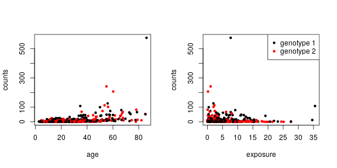

## Your turn: use `glm( )`

$$\begin{aligned}
Z_i &\sim \Poisson(\mu_i) \\
\mu_i &= \exp\left( a_{g_i} + b \times \text{age}_i + c_{g_i} \times \text{exposure}_i \right)
\end{aligned}$$

Here are the data:

```r
countdata <- read.table("poisson_counts.tsv", header=TRUE)
head(countdata)
```

```
##   genotype       age    exposure counts
## 1        1 32.002416  0.08573067     12
## 2        1 31.946713  3.34821235      0
## 3        2  9.937669  1.14303355      8
## 4        2 26.423782 27.50630521      0
## 5        1 41.199082  2.97643962      2
## 6        1  6.613676  0.62972565      0
```

## Write a Stan block

1. Counts are **Poisson**,
2. with mean that depends on age and exposure,
3. but effect of exposure depends on genotype.

$$\begin{aligned}
Z_i &\sim \Poisson(y_i) \\
y_i &= \exp(a_{g_i} + b \times \text{age}_i \\
&\qquad {} + c_{g_i} \times \text{exposure}_i )
\end{aligned}$$

```
data {
    int N;
    int counts[N];
    vector[N] age;
    vector[N] exposure;
    int genotype[N];
    int ngeno;
}
parameters {
    real a[ngeno]; // intercepts
    real b; // slope for age
    real c[ngeno]; // slopes for exposure
}
model {
    vector[N] y; // means
    y = exp(a[genotype] + b .* age + c[genotype] .* exposure);
    counts ~ poisson(y);
    // implicitly flat priors
}
```

## The result

*Note:* scaling the data helps Stan find the right scale to move on.

```r
scaled_data <- with(data, list(N=length(counts),
                               counts=counts,
                               age=(age - mean(age))/sd(age),
                               expo=(exposure - mean(exposure))/sd(exposure),
                               geno=genotype))
fit1 <- stan(file="simple_poisson.stan",
             data=scaled_data,
             control=list(max_treedepth=12),
             iter=1000, chains=3)
```

```r
post1 <- extract(fit1)
print(fit1)
```

```
## Inference for Stan model: simple_poisson.
## 3 chains, each with iter=1000; warmup=500; thin=1;
## post-warmup draws per chain=500, total post-warmup draws=1500.
##
##          mean se_mean   sd     2.5%      25%      50%      75%    97.5% n_eff Rhat
## a[1]     2.13    0.00 0.02     2.09     2.12     2.13     2.15     2.17  1324 1.00
## a[2]     1.73    0.00 0.03     1.67     1.71     1.73     1.75     1.78  1009 1.00
## b        0.82    0.00 0.01     0.80     0.82     0.82     0.83     0.84  1304 1.00
## c[1]     0.10    0.00 0.01     0.08     0.09     0.10     0.11     0.12  1492 1.00
## c[2]    -0.70    0.00 0.03    -0.76    -0.72    -0.70    -0.67    -0.63  1217 1.00
## lp__ 12164.36    0.06 1.62 12160.26 12163.55 12164.70 12165.58 12166.45   748 1.01
##
## Samples were drawn using NUTS(diag_e) at Mon Nov 25 21:24:14 2019.
## For each parameter, n_eff is a crude measure of effective sample size,
## and Rhat is the potential scale reduction factor on split chains (at
## convergence, Rhat=1).
```

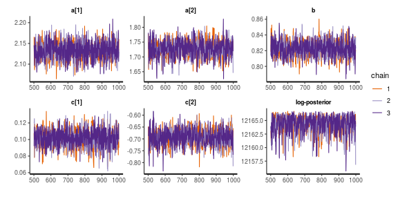

```r
stan_trace(fit1, pars=c("a","b","c","lp__"), inc_warmup=FALSE)
```

## How’d we do?

Here are posterior distributions of the parameters, with **the true values in red**.

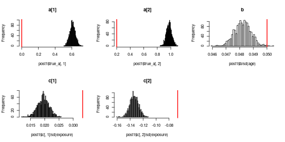

*What happened?*

# Goodness of fit

## Posterior predictive simulations

Let’s simulate up data *under this model* to check for goodness of fit.

We expect to **not** see a good fit. (*Why?*)

## 100 datasets from the posterior distribution

```r
params1 <- list(a=colMeans(post1$a),
                b=mean(post1$b),
                c=colMeans(post1$c))
mu1 <- with(list2env(scaled_data),
                exp(params1$a[geno]
                    + params1$b * age
                    + params1$c[geno] * expo))
# 100 datasets:
sim1 <- replicate(100, rpois(length(mu1), mu1))
```

```
model {
    vector[N] mu;
    mu = exp(a[geno]
             + b * age
             + c[geno]
               .* expo);
    counts ~ poisson(mu);
```

## True data are *overdispersed* relative to our simulations

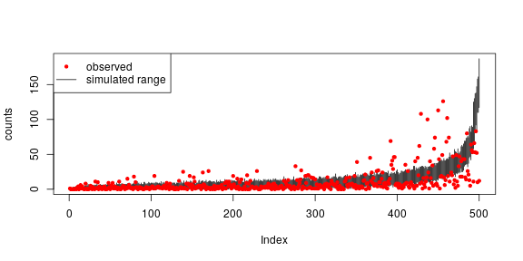

```r
plot(data$counts[order(mu1)], ylab="counts", ylim=range(sim1), type='n')
segments(x0=seq_len(nrow(data)),
         y0=rowMins(sim1)[order(mu1)],
         y1=rowMaxs(sim1)[order(mu1)])
points(data$counts[order(mu1)], pch=20, col='red')
legend("topleft", pch=c(20,NA), lty=c(NA,1), legend=c("observed", "simulated range"), col=c('red', 'black'))
```

# Stan interlude

## The important program blocks

```
data {
    // what we know: the input
    // declarations only
}
parameters {
    // what we want to know about:
    // defines the space Stan random walks in
    // declarations only
}
model {
    // stuff to calculate the priors and the likelihoods
    // happens every step
}
```

## The program blocks

```
functions {
    // user-defined functions
}
data {
    // what we know: the input
    // declarations only
}
transformed data {
    // calculations to do once, at the start
}
parameters {
    // what we want to know about:
    // defines the space Stan random walks in
    // declarations only
}
transformed parameters {
    // other things that we want the posterior distribution of
    // happens every step
}
model {
    // stuff to calculate the priors and the likelihoods
    // happens every step
}
generated quantities {
    // more things we want the posterior distribution of
    // but that don't affect the random walk
}
```

## On priors

Under the hood,

```
    z ~ poisson(mu);
```

is equivalent to

```
    target += poisson_lpdf(z | mu);
```

(`lpdf` = log posterior density function).

So, if you *don’t* put a prior on something, it implicitly has a *uniform* prior (i.e., a flat prior).

## Error messages

These are important. Pay attention to them, and fix the problems.

Run code in the *console*. Rstudio often hides useful information.

## Parameterization matters

More on this later.

# Including overdispersion

## How can we include overdispersion?

1. Counts are **Poisson**,
2. with mean that depends on age and exposure,
3. but effect of exposure depends on genotype.
4. Actually, counts are *overdispersed*, so make the means *random*, and lognormally distributed.

$$\begin{aligned}
Z_i &\sim \Poisson(\mu_i) \\
\mu_i &= \exp\left( a_{g_i} + b \times \text{age}_i + c_{g_i} \times \text{exposure}_i \right)
\end{aligned}$$

1. Counts are **Poisson**,
2. with mean that depends on age and exposure,
3. but effect of exposure depends on genotype.
4. Actually, counts are *overdispersed*, so the means are *random*, and lognormally distributed.

$$\begin{aligned}
Z_i &\sim \Poisson(\mu_i) \\
\mu_i &= \exp(W_i) \\
W_i &\sim \Normal(y_i, \sigma) \\
y_i &= a_{g_i} + b \times \text{age}_i + c_{g_i} \times \text{exposure}_i
\end{aligned}$$

1. Counts are **Poisson**,
2. with mean that depends on age and exposure,
3. but effect of exposure depends on genotype.
4. Actually, counts are *overdispersed*, so the means are *random*, and lognormally distributed.

$$\begin{aligned}
Z_i &\sim \Poisson(\mu_i) \\
\mu_i &\sim \log\Normal(y_i, \sigma) \\
y_i &= a_{g_i} + b \times \text{age}_i + c_{g_i} \times \text{exposure}_i
\end{aligned}$$

## Add overdispersion

$$\begin{aligned}
Z_i &\sim \Poisson(\mu_i) \\
\mu_i &\sim \log\Normal(y_i, \sigma) \\
y_i &= a_{g_i} + b \times \text{age}_i \\
&\qquad {} + c_{g_i} \times \text{exposure}_i
\end{aligned}$$

```
overdispersed_model <- stan_model(model_code="
data {
    int N; // number of data points
    vector[N] age;
    vector[N] exposure;
    int counts[N];
    int genotype[N];
    int ngenotypes;
}
parameters {
    vector[ngenotypes] a; // intercepts
    real b; // slope for age
    vector[ngenotypes] c; // slopes for exposure
    real<lower=0> sigma; // SD on lognormal
    vector[N] mu; // mean of the poissons
}
model {
    vector[N] y; // mean of the lognormals
    y = a[genotype] + b * age + c[genotype] .* exposure;
    mu ~ lognormal(y, sigma);
    counts ~ poisson(mu);
    a ~ normal(0, 100);
    b ~ normal(0, 10);
    c ~ normal(0, 20);
    sigma ~ normal(0, 10);
}")
```

```r
fit2 <- stan(file="lognormal_poisson.stan",
             data=scaled_data,
             iter=1000, chains=3)
```

```r
post2 <- rstan::extract(fit2)
print(fit2)
```

```
## Inference for Stan model: lognormal_poisson.
## 3 chains, each with iter=1000; warmup=500; thin=1;
## post-warmup draws per chain=500, total post-warmup draws=1500.
##
##             mean se_mean    sd     2.5%      25%      50%      75%    97.5% n_eff Rhat
## mu[1]      11.28    0.05  3.20     5.92     8.99    10.91    13.28    18.41  3883 1.00
## mu[2]       1.37    0.02  0.92     0.26     0.73     1.18     1.78     3.73  2732 1.00
## mu[3]       6.94    0.04  2.45     3.03     5.15     6.64     8.46    12.27  3678 1.00
## mu[4]       0.25    0.01  0.30     0.02     0.09     0.16     0.31     1.01  1413 1.00
## mu[5]       3.01    0.03  1.55     0.85     1.89     2.72     3.84     6.82  2707 1.00
## mu[6]       0.81    0.02  0.66     0.11     0.35     0.60     1.11     2.51  1659 1.00
## mu[7]       9.86    0.06  3.09     4.87     7.68     9.47    11.63    17.04  2644 1.00
## mu[8]       5.52    0.04  2.22     2.22     3.87     5.14     6.93    10.55  3025 1.00
## mu[9]       0.73    0.01  0.60     0.09     0.32     0.56     0.95     2.19  1946 1.00
## mu[10]      5.54    0.04  2.13     2.25     4.06     5.24     6.68    10.48  2567 1.00
## mu[11]      2.04    0.02  1.16     0.48     1.20     1.81     2.68     4.78  2993 1.00
## mu[12]    100.31    0.14  9.75    82.34    93.40   100.12   106.68   120.04  4764 1.00
## mu[13]      1.46    0.02  0.93     0.32     0.79     1.25     1.88     3.85  2678 1.00
## mu[14]      1.55    0.01  1.01     0.28     0.85     1.34     2.02     4.01  4665 1.00
## mu[15]      1.18    0.02  0.86     0.21     0.57     0.96     1.55     3.39  2574 1.00
## mu[16]      7.95    0.05  2.59     3.79     6.09     7.67     9.50    13.84  3248 1.00
## mu[17]      7.41    0.04  2.35     3.36     5.76     7.24     8.77    12.86  3717 1.00
## mu[18]     37.26    0.11  5.97    26.47    33.02    37.00    41.04    49.51  2825 1.00
## mu[19]      5.91    0.05  2.29     2.39     4.27     5.66     7.26    11.08  2442 1.00
## mu[20]      2.44    0.02  1.24     0.73     1.55     2.22     3.08     5.49  3713 1.00
## mu[21]      1.26    0.02  0.90     0.21     0.63     1.04     1.64     3.52  2604 1.00
## mu[22]      0.88    0.01  0.69     0.12     0.40     0.69     1.17     2.65  2117 1.00
## mu[23]     15.97    0.07  4.13     8.84    13.09    15.49    18.39    25.53  3278 1.00
## mu[24]    240.01    0.22 14.98   211.44   230.30   239.73   249.89   270.95  4461 1.00
## mu[25]      3.84    0.03  1.69     1.25     2.63     3.63     4.73     7.64  3592 1.00
## mu[26]    572.81    0.36 22.26   532.12   557.31   572.51   587.54   615.86  3915 1.00
## mu[27]     16.66    0.07  3.97     9.62    13.99    16.43    19.03    25.48  3574 1.00
## mu[28]      3.63    0.03  1.65     1.15     2.46     3.36     4.45     7.66  3511 1.00
## mu[29]     13.27    0.06  3.53     7.37    10.66    12.99    15.56    20.83  3442 1.00
## mu[30]      0.90    0.01  0.72     0.14     0.42     0.71     1.17     2.73  2481 1.00
## mu[31]      1.57    0.02  1.01     0.32     0.82     1.32     2.09     4.22  2510 1.00
## mu[32]      8.25    0.05  2.65     4.00     6.29     7.89     9.93    14.12  2589 1.00
## mu[33]      4.37    0.04  1.88     1.51     3.01     4.10     5.45     8.74  2850 1.00
## mu[34]      2.51    0.02  1.36     0.62     1.54     2.25     3.20     5.98  3095 1.00
## mu[35]      2.10    0.02  1.20     0.47     1.26     1.88     2.68     5.11  2809 1.00
```

[output cut: 462 more lines]

```
## mu[498]     2.39    0.03  1.37     0.57     1.41     2.14     3.03     5.90  2983 1.00
## mu[499]     1.13    0.02  0.79     0.18     0.58     0.94     1.52     3.09  2495 1.00
## mu[500]     1.26    0.02  0.87     0.22     0.63     1.05     1.60     3.64  2646 1.00
## a[1]        1.54    0.00  0.07     1.40     1.49     1.54     1.59     1.69  1487 1.00
## a[2]        1.28    0.00  0.08     1.12     1.23     1.28     1.33     1.43  1459 1.00
## b           0.81    0.00  0.05     0.71     0.78     0.81     0.85     0.92  2683 1.00
## c[1]        0.15    0.00  0.07     0.02     0.11     0.15     0.20     0.28  2168 1.00
## c[2]       -0.62    0.00  0.09    -0.80    -0.68    -0.62    -0.55    -0.43  1256 1.00
## sigma       1.04    0.00  0.05     0.95     1.01     1.04     1.07     1.14  1136 1.00
## lp__    15065.69    0.92 18.24 15028.83 15054.00 15066.51 15078.23 15100.35   395 1.01
##
## Samples were drawn using NUTS(diag_e) at Mon Nov 25 21:34:21 2019.
## For each parameter, n_eff is a crude measure of effective sample size,
## and Rhat is the potential scale reduction factor on split chains (at
## convergence, Rhat=1).
```

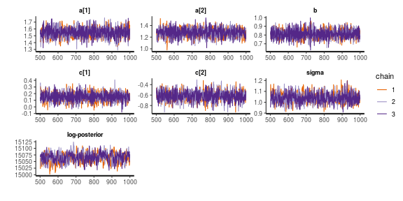

```r
stan_trace(fit2, pars=c("a", "b", "c", "sigma", "lp__"))
```

## How’d we do *now*?

Here are posterior distributions from the full model, with the true values in red.

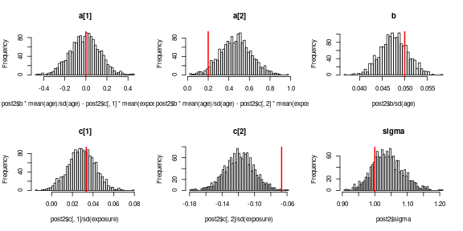

## Posterior predictive simulations, again

```r
# 100 datasets:
params2 <- list(a=colMeans(post2$a),
                b=mean(post2$b),
                c=colMeans(post2$c),
                sigma=mean(post2$sigma))
y2 <- with(list2env(scaled_data),
                params2$a[geno]
                    + params2$b * age
                    + params2$c[geno] * expo)
sim2 <- replicate(100, {
           mu = exp(rnorm(length(y2),
                          mean=y2,
                          sd=params2$sigma))
           rpois(length(mu), mu)
         })
```

```
model {
    vector[N] y;
    y = a[geno] + b * age + c[geno] .* expo;
    mu ~ lognormal(y, sigma);
    counts ~ poisson(mu);
}
```

## Now we cover the true data

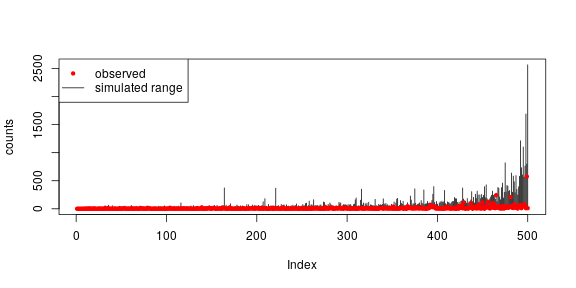

```r
plot(data$counts[order(mu1)], ylab="counts", ylim=range(sim2), type='n')
segments(x0=seq_len(nrow(data)),
         y0=rowMins(sim2)[order(mu1)],
         y1=rowMaxs(sim2)[order(mu1)])
points(data$counts[order(mu1)], pch=20, col='red')
legend("topleft", pch=c(20,NA), lty=c(NA,1), legend=c("observed", "simulated range"), col=c('red', 'black'))
```

## Now we cover the true data

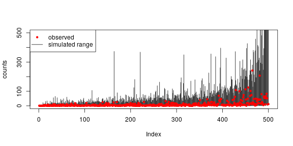

```r
plot(data$counts[order(mu1)], ylab="counts", ylim=c(0,500), type='n')
segments(x0=seq_len(nrow(data)),
         y0=rowMins(sim2)[order(mu1)],
         y1=rowMaxs(sim2)[order(mu1)])
points(data$counts[order(mu1)], pch=20, col='red')
legend("topleft", pch=c(20,NA), lty=c(NA,1), legend=c("observed", "simulated range"), col=c('red', 'black'))
```